# EDA — Dataset de mandioca · Clasificación de enfermedades (5 clases)

**Trabajo Final Integrador — IC522 · Inteligencia Computacional** · WLODECK, Fabricio Joaquín

Objetivo: analizar la integridad, composición y calidad del dataset de imágenes de hojas de mandioca para preparar el pipeline de clasificación de la consigna.

**Diccionario de clases (usado en todas las salidas):**

[output not shown]

**Cómo ejecutar**

- **VS Code:** abrir la carpeta del proyecto, instalar Python y Jupyter, confiar en la carpeta (Workspace Trust), abrir el `.ipynb` y *Run All* (o ejecutar con nbconvert, ver al final).
- **Google Colab:** *Archivo → Subir a Google Drive* o subir el notebook; subir `labels.csv` (y opcionalmente `mandioca.zip` para las celdas de imágenes, que se desactivan solas si no encuentran la carpeta).

**Entregables:** `01_EDA_mandioca.ipynb` (ejecutado) + `.html` + `.pdf`.

> Las celdas de **imágenes** (Fase 5) se autodesactivan si no existe la carpeta de imágenes.

```python
import os, re, time, random, hashlib
from pathlib import Path
from collections import Counter, defaultdict

import numpy as np
import pandas as pd
import matplotlib.pyplot as plt

SEED = 42
random.seed(SEED)
np.random.seed(SEED)

NOMBRE = {
    0: "CBB (bacteriosis)",
    1: "CBSD (rayas marrones)",
    2: "CGM (moteado verde)",
    3: "CMD (mosaico)",
    4: "Saludable",
}
PALETA = {0: "#D73027", 1: "#FC8D59", 2: "#FCC163", 3: "#4575B4", 4: "#1A9850"}
ORDEN = sorted(NOMBRE)

pd.set_option("display.max_columns", 20)
pd.set_option("display.width", 140)
pd.set_option("display.max_colwidth", 60)
plt.rcParams.update({
    "figure.dpi": 110,
    "savefig.dpi": 110,
    "figure.facecolor": "white",
    "axes.grid": True,
    "grid.alpha": 0.3,
    "font.size": 10,
})

def pct(s):
    return (100 * s / s.sum()).round(2)

print("Semilla:", SEED, "| pandas", pd.__version__, "| numpy", np.__version__)
```

```
Semilla: 42 | pandas 3.0.6 | numpy 2.5.3
```

## Fase 0 — Entorno y carga de datos

Detección de entorno (Colab / local) y ubicación de `labels.csv` con rutas candidatas + respaldo absoluto.

```python
def detectar_entorno():
    try:
        import google.colab  # noqa: F401
        return "colab"
    except Exception:
        return "local"

ENTORNO = detectar_entorno()
print("Entorno detectado:", ENTORNO)

CANDIDATOS = [
    Path("datos/labels.csv"),
    Path("labels.csv"),
    Path("../datos/labels.csv"),
    Path(r"C:\Users\Fabricio\Desktop\final_inteligencia\datos\labels.csv"),
]

if ENTORNO == "colab":
    print("En Colab subi 'labels.csv' por el panel de archivos (o ejecuta files.upload()).")
    try:
        from google.colab import files
        if not any(p.exists() for p in CANDIDATOS):
            uploaded = files.upload()
            CANDIDATOS.insert(0, Path(list(uploaded)[0]))
    except Exception as e:
        print("No se pudo abrir files.upload():", e)

RUTA_CSV = next((p for p in CANDIDATOS if p.exists()), None)
assert RUTA_CSV is not None, "No se encontro labels.csv en ninguna ruta candidata"
df = pd.read_csv(RUTA_CSV)
print("CSV:", RUTA_CSV.resolve())
print("Shape:", df.shape)
```

```
Entorno detectado: local
CSV: C:\Users\Fabricio\Desktop\final_inteligencia\datos\labels.csv
Shape: (26337, 3)
```

## Fase 1 — Identidad del dataset y diccionario

Primer contacto: dimensiones, tipos, nulos y muestra de filas.

```python
print("Forma:", df.shape)
print("\nColumnas:", list(df.columns))
display(df.head())
display(df.tail())

tabla_diccionario = pd.DataFrame({
    "columna": ["image_id", "label", "source"],
    "tipo": [str(df.image_id.dtype), str(df.label.dtype), str(df.source.dtype)],
    "descripcion": [
        "nombre del archivo .jpg en la carpeta images/",
        "clase entera 0..4 (mapear con NOMBRE de la celda 1)",
        "fuente/campana de captura (2019 o 2020)",
    ],
    "n_unicos": [df.image_id.nunique(), df.label.nunique(), df.source.nunique()],
})
display(tabla_diccionario)
```

```
Forma: (26337, 3)

Columnas: ['image_id', 'label', 'source']
```

|  | image_id | label | source |
| --- | --- | --- | --- |
| 0 | 1000015157.jpg | 0 | 2020 |
| 1 | 1000201771.jpg | 3 | 2020 |
| 2 | 100042118.jpg | 1 | 2020 |
| 3 | 1000723321.jpg | 1 | 2020 |
| 4 | 1000812911.jpg | 3 | 2020 |

|  | image_id | label | source |
| --- | --- | --- | --- |
| 26332 | train-cbb-114.jpg | 0 | 2019 |
| 26333 | train-cmd-661.jpg | 3 | 2019 |
| 26334 | train-cmd-1716.jpg | 3 | 2019 |
| 26335 | train-healthy-236.jpg | 4 | 2019 |
| 26336 | train-cgm-498.jpg | 2 | 2019 |

|  | columna | tipo | descripcion | n_unicos |
| --- | --- | --- | --- | --- |
| 0 | image_id | str | nombre del archivo .jpg en la carpeta images/ | 26337 |
| 1 | label | int64 | clase entera 0..4 (mapear con NOMBRE de la celda 1) | 5 |
| 2 | source | int64 | fuente/campana de captura (2019 o 2020) | 2 |

## Fase 2 — Integridad y calidad (antes de mirar distribuciones)

Chequeos de nulos, duplicados de id, cruce CSV ↔ disco, duplicados exactos (SHA-1 completo), legibilidad de las imágenes y coherencia **nombre del archivo ↔ etiqueta**.

```python
print("Nulos por columna:\n", df.isna().sum().to_string())
print("\nimage_id duplicados:", int(df.image_id.duplicated().sum()))
print("Valores de label:", sorted(df.label.unique()))
print("Valores de source:", sorted(df.source.unique()))
print("rango de label valido [0,4]:", bool(df.label.between(0, 4).all()))
print("extensiones presentes:", Counter(Path(x).suffix for x in df.image_id))
```

```
Nulos por columna:
 image_id    0
label       0
source      0

image_id duplicados: 0
Valores de label: [np.int64(0), np.int64(1), np.int64(2), np.int64(3), np.int64(4)]
Valores de source: [np.int64(2019), np.int64(2020)]
rango de label valido [0,4]: True
```

```
extensiones presentes:
```

```
 Counter({'.jpg': 26337})
```

```python
def buscar_carpeta_imagenes():
    cands = [
        Path("datos/images"),
        Path("images"),
        Path("datos/mandioca/images"),
        Path("mandioca/images"),
        Path(r"C:\Users\Fabricio\Desktop\final_inteligencia\datos\images"),
    ]
    return next((p for p in cands if p.exists()), None)

RAIZ_IMG = buscar_carpeta_imagenes()
if RAIZ_IMG is None:
    print("AVISO: no se encontro la carpeta de imagenes.")
    print("Las fases de imagenes se omitiran (en Colab: subir mandioca.zip y descomprimir).")
else:
    disco = set(os.listdir(RAIZ_IMG))
    en_csv = set(df.image_id)
    print("Carpeta:", RAIZ_IMG.resolve())
    print("Archivos en disco:", len(disco), "| image_id en CSV:", len(en_csv))
    print("Faltan en disco:", len(en_csv - disco), "| Sobran en disco:", len(disco - en_csv))
    print("Extensiones no .jpg:", {e for e in disco if not e.lower().endswith(".jpg")} or "ninguna")
    print("Total GB:", round(sum(os.path.getsize(RAIZ_IMG / f) for f in disco) / 1024**3, 2))
```

```
Carpeta: C:\Users\Fabricio\Desktop\final_inteligencia\datos\images
Archivos en disco: 26337 | image_id en CSV: 26337
Faltan en disco: 0 | Sobran en disco: 0
Extensiones no .jpg: ninguna
```

```
Total GB: 3.09
```

### 2.1 Duplicados exactos (SHA-1 completo)

Lectura de **todos** los archivos en chunks de 1 MB (≈30 s en este equipo para 3.09 GiB). Se reportan: archivos, hashes únicos, grupos duplicados, archivos involucrados y excedentes.

```python
if RAIZ_IMG is None:
    print("Omitido: no hay carpeta de imagenes.")
else:
    t0 = time.time()
    hashes = defaultdict(list)
    files_all = sorted(f for f in os.listdir(RAIZ_IMG))
    for i, f in enumerate(files_all, 1):
        h = hashlib.sha1()
        with open(RAIZ_IMG / f, "rb") as fh:
            for chunk in iter(lambda: fh.read(1 << 20), b""):
                h.update(chunk)
        hashes[h.hexdigest()].append(f)
        if i % 5000 == 0:
            print(f"  {i}/{len(files_all)} archivos hasheados...")

    dups = {k: v for k, v in hashes.items() if len(v) > 1}
    print(f"Archivos procesados: {len(files_all)}")
    print(f"Hashes unicos:       {len(hashes)}")
    print(f"Grupos duplicados:   {len(dups)}")
    print(f"Archivos en duplicados: {sum(len(v) for v in dups.values())}")
    print(f"Excedentes (a borrar si hubiera): {sum(len(v) - 1 for v in dups.values())}")
    for k, v in list(dups.items())[:10]:
        print("  dup:", v)
    print(f"Tiempo: {time.time() - t0:.1f} s")
```

```
  5000/26337 archivos hasheados...
```

```
  10000/26337 archivos hasheados...
```

```
  15000/26337 archivos hasheados...
```

```
  20000/26337 archivos hasheados...
```

```
  25000/26337 archivos hasheados...
```

```
Archivos procesados: 26337
Hashes unicos:       26337
Grupos duplicados:   0
Archivos en duplicados: 0
Excedentes (a borrar si hubiera): 0
Tiempo: 25.8 s
```

### 2.2 Legibilidad de las imágenes (muestra aleatoria, semilla fija)

```python
try:
    from PIL import Image
    PIL_OK = True
except Exception as e:
    PIL_OK = False
    print("Pillow no disponible:", e)

if RAIZ_IMG is None or not PIL_OK:
    print("Omitido: sin carpeta de imagenes o sin Pillow.")
else:
    t0 = time.time()
    files_all = [f for f in os.listdir(RAIZ_IMG) if f.lower().endswith(".jpg")]
    muestra = random.sample(files_all, min(3000, len(files_all)))
    modos, rotas = Counter(), []
    for f in muestra:
        try:
            with Image.open(RAIZ_IMG / f) as im:
                modo = im.mode
            with Image.open(RAIZ_IMG / f) as im:
                im.verify()
            modos[modo] += 1
        except Exception:
            rotas.append(f)
    print("Muestra verificada:", len(muestra))
    print("Ilegibles/corruptas:", len(rotas), rotas[:10])
    print("Modos de color:", dict(modos))
    print(f"Tiempo: {time.time() - t0:.1f} s")
```

```
Muestra verificada: 3000
Ilegibles/corruptas: 0 []
Modos de color: {'RGB': 3000}
Tiempo: 1.7 s
```

### 2.3 Coherencia nombre del archivo ↔ etiqueta (chequeo de filtrado de la etiqueta)

El subconjunto `source = 2019` tiene nombres `train-<tipo>-NNN.jpg`, que **contienen la clase**. Si el crosstab es diagonal, el nombre filtra la etiqueta: jamás debe usarse como feature.

```python
tipo = df.image_id.str.extract(r"^train-([a-z]+)-\d+\.jpg$")[0]
con_patron = tipo.notna()
print("Archivos con nombre descriptivo:", int(con_patron.sum()), "| numericos:", int((~con_patron).sum()))

ct = pd.crosstab(tipo.fillna("(numerico 2020)"), df.label, margins=True)
ct.rename(columns=NOMBRE, inplace=True)
display(ct)

MAPEO_NOMBRE = {"cbb": 0, "cbsd": 1, "cgm": 2, "cmd": 3, "healthy": 4}
sub = df[con_patron].copy()
sub["label_esperado"] = sub.image_id.str.extract(r"^train-([a-z]+)-\d+\.jpg$")[0].map(MAPEO_NOMBRE)
coherencia = float((sub.label == sub.label_esperado).mean())
print(f"Coherencia nombre->label en los descriptivos: {100 * coherencia:.2f} %")
print("Todos los descriptivos pertenecen a source 2019:",
      bool((df.loc[con_patron, "source"] == 2019).all()))
```

```
Archivos con nombre descriptivo: 4940 | numericos: 21397
```

| label 0 | CBB (bacteriosis) | CBSD (rayas marrones) | CGM (moteado verde) | CMD (mosaico) | Saludable | All |
| --- | --- | --- | --- | --- | --- | --- |
| (numerico 2020) | 1087 | 2189 | 2386 | 13158 | 2577 | 21397 |
| cbb | 405 | 0 | 0 | 0 | 0 | 405 |
| cbsd | 0 | 1287 | 0 | 0 | 0 | 1287 |
| cgm | 0 | 0 | 631 | 0 | 0 | 631 |
| cmd | 0 | 0 | 0 | 2304 | 0 | 2304 |
| healthy | 0 | 0 | 0 | 0 | 313 | 313 |
| All | 1492 | 3476 | 3017 | 15462 | 2890 | 26337 |

```
Coherencia nombre->label en los descriptivos: 100.00 %
Todos los descriptivos pertenecen a source 2019: True
```

## Fase 3 — Composición y desbalance de clases

**Normalización:** todos los % de esta sección son **sobre el total de 26,337 registros**, salvo que se indique otra base (se aclara celda por celda).

|  | n | % |
| --- | --- | --- |
| CBB (bacteriosis) | 1492 | 5.67 |
| CBSD (rayas marrones) | 3476 | 13.20 |
| CGM (moteado verde) | 3017 | 11.46 |
| CMD (mosaico) | 15462 | 58.71 |
| Saludable | 2890 | 10.97 |

```
Clase mayoritaria: CMD (mosaico) | minoritaria: CBB (bacteriosis)
Ratio desbalance max/min: 10.36 : 1
```

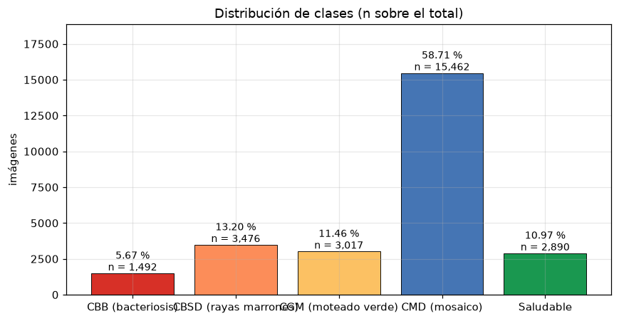

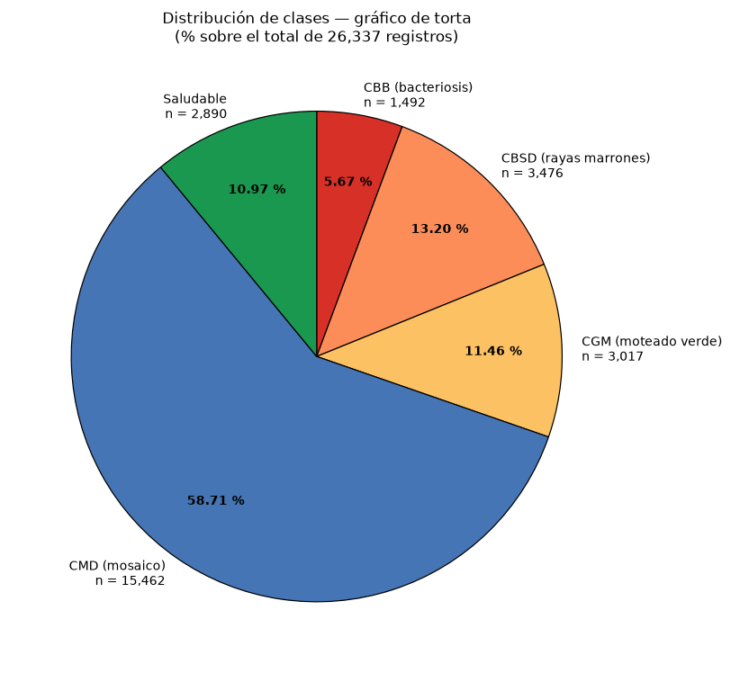

```python
t_clase = df.label.value_counts().sort_index().rename_axis("label").to_frame("n")
t_clase["%"] = pct(t_clase.n)
t_clase.index = [NOMBRE[i] for i in t_clase.index]
display(t_clase)

ratio = t_clase.n.max() / t_clase.n.min()
print(f"Clase mayoritaria: {t_clase.n.idxmax()} | minoritaria: {t_clase.n.idxmin()}")
print(f"Ratio desbalance max/min: {ratio:.2f} : 1")

fig, ax = plt.subplots(figsize=(8, 4.2))
etiquetas = [NOMBRE[i] for i in ORDEN]
valores = [int(t_clase.loc[e, "n"]) for e in etiquetas]
ax.bar(etiquetas, valores, color=[PALETA[i] for i in ORDEN], edgecolor="black", linewidth=0.6)
for x, v in zip(range(len(valores)), valores):
    ax.text(x, v + 200, f"{100 * v / sum(valores):.2f} %\nn = {v:,}", ha="center", fontsize=9)
ax.set_title("Distribución de clases (n sobre el total)")
ax.set_ylabel("imágenes")
ax.set_ylim(0, max(valores) * 1.22)
plt.tight_layout()
plt.show()

fig, ax = plt.subplots(figsize=(7.5, 7.5))
etiquetas_pie = [f"{e}\nn = {v:,}" for e, v in zip(etiquetas, valores)]
wedges, textos, autopcts = ax.pie(
    valores,
    labels=etiquetas_pie,
    colors=[PALETA[i] for i in ORDEN],
    autopct=lambda p: f"{p:.2f} %",
    startangle=90,
    counterclock=False,
    wedgeprops={"edgecolor": "black", "linewidth": 0.8},
    pctdistance=0.72,
    labeldistance=1.08,
    textprops={"fontsize": 9},
)
for t in autopcts:
    t.set_color("black")
    t.set_fontsize(9)
    t.set_fontweight("bold")
ax.set_title("Distribución de clases — gráfico de torta\n(% sobre el total de 26,337 registros)", fontsize=11)
plt.tight_layout()
plt.show()
```

**Implicancias según la consigna**

- El dataset está **muy desbalanceado** (CMD ≈ 59 % vs CBB ≈ 6 %): el *accuracy* engaña.
- Métricas a reportar en el trabajo: **macro-F1, balanced accuracy, ROC-AUC / PR-AUC y matriz de confusión normalizada por fila**.
- Costo asimétrico: lo peor es confundir **saludable ↔ enferma** o perder una enfermedad (falsos negativos), porque implica tratar o no tratar cultivos de forma equivocada.

```python
ct_ns = pd.crosstab(df.label, df.source, margins=True, margins_name="Total")
ct_ns.rename(index=NOMBRE, inplace=True)
print("Cruce label x source — n (absolutos):")
display(ct_ns)

ct_col = (pd.crosstab(df.label, df.source, normalize="columns") * 100).round(2)
ct_col.rename(index=NOMBRE, inplace=True)
print("Mismo cruce — % normalizado POR COLUMNA (distribucion de clases dentro de cada fuente):")
display(ct_col)

ct_row = (pd.crosstab(df.label, df.source, normalize="index") * 100).round(2)
ct_row.rename(index=NOMBRE, inplace=True)
print("Mismo cruce — % normalizado POR FILA (como se reparte cada clase entre las fuentes):")
display(ct_row)
```

```
Cruce label x source — n (absolutos):
```

| source label | 2019 | 2020 | Total |
| --- | --- | --- | --- |
| CBB (bacteriosis) | 405 | 1087 | 1492 |
| CBSD (rayas marrones) | 1287 | 2189 | 3476 |
| CGM (moteado verde) | 631 | 2386 | 3017 |
| CMD (mosaico) | 2304 | 13158 | 15462 |
| Saludable | 313 | 2577 | 2890 |
| Total | 4940 | 21397 | 26337 |

```
Mismo cruce — % normalizado POR COLUMNA (distribucion de clases dentro de cada fuente):
```

| source label | 2019 | 2020 |
| --- | --- | --- |
| CBB (bacteriosis) | 8.20 | 5.08 |
| CBSD (rayas marrones) | 26.05 | 10.23 |
| CGM (moteado verde) | 12.77 | 11.15 |
| CMD (mosaico) | 46.64 | 61.49 |
| Saludable | 6.34 | 12.04 |

```
Mismo cruce — % normalizado POR FILA (como se reparte cada clase entre las fuentes):
```

| source label | 2019 | 2020 |
| --- | --- | --- |
| CBB (bacteriosis) | 27.14 | 72.86 |
| CBSD (rayas marrones) | 37.03 | 62.97 |
| CGM (moteado verde) | 20.91 | 79.09 |
| CMD (mosaico) | 14.90 | 85.10 |
| Saludable | 10.83 | 89.17 |

## Fase 4 — Fuentes de captura y sesgo de dominio

`source` separa dos campañas/años. Las de **2019** traen nombres descriptivos y las de **2020** numéricos, lo que sugiere que son datasets originales distintos (cámara, fondo e iluminación diferentes). Si el split no controla esta variable, los resultados pueden inflarse.

| source | n | % |
| --- | --- | --- |
| 2019 | 4940 | 18.76 |
| 2020 | 21397 | 81.24 |

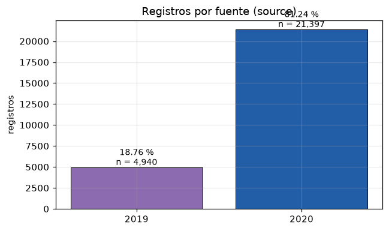

```
¿Toda clase esta presente en ambas fuentes?:
```

```
 True
Mínimo de registros por (clase, fuente): 313
```

```python
t_fuente = df.source.value_counts().sort_index().rename_axis("source").to_frame("n")
t_fuente["%"] = pct(t_fuente.n)
display(t_fuente)

fig, ax = plt.subplots(figsize=(6, 3.6))
ax.bar([str(s) for s in t_fuente.index], t_fuente.n, color=["#8C6BB1", "#225EA8"],
       edgecolor="black", linewidth=0.6)
for i, (s, row) in enumerate(t_fuente.iterrows()):
    ax.text(i, row.n + 300, f"{row['%']:.2f} %\nn = {int(row.n):,}", ha="center", fontsize=9)
ax.set_title("Registros por fuente (source)")
ax.set_ylabel("registros")
plt.tight_layout()
plt.show()

presentes = pd.crosstab(df.label, df.source) > 0
print("¿Toda clase esta presente en ambas fuentes?:", bool(presentes.all().all()))
print("Mínimo de registros por (clase, fuente):", int(pd.crosstab(df.label, df.source).min().min()))
```

## Fase 5 — Análisis de las imágenes (núcleo del EDA)

Esta fase **se autodesactiva** si no hay carpeta de imágenes (en Colab: subir `mandioca.zip` y descomprimir). Analiza dimensiones, aspecto, brillo/contraste por clase, montajes visuales por clase e imágenes no informativas.

```
  1000/3000
```

```
  2000/3000
```

```
  3000/3000
Muestra: 3000 imagenes
Tamaños distintos en la muestra: 132
Mas frecuentes: [('800x600', '80.4 %'), ('888x500', '3.7 %'), ('500x666', '3.3 %'), ('625x500', '2.8 %'), ('666x500', '1.9 %'), ('500x500', '1.7 %')]
Mediana ancho x alto: 800 x 600
Mediana de peso: 119.5 KB | min 35.1 | max 348.8 KB
```

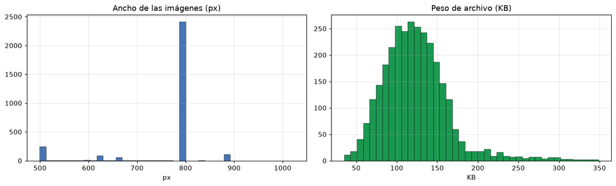

```python
disp_img = RAIZ_IMG is not None and PIL_OK
if not disp_img:
    print("OMITIDO: sin carpeta de imagenes o sin Pillow.")
else:
    files_all = [f for f in os.listdir(RAIZ_IMG) if f.lower().endswith(".jpg")]
    muestra = random.sample(files_all, min(3000, len(files_all)))
    dims, anchos, altos, kbs = Counter(), [], [], []
    for i, f in enumerate(muestra, 1):
        with Image.open(RAIZ_IMG / f) as im:
            dims[(im.width, im.height)] += 1
            anchos.append(im.width)
            altos.append(im.height)
        kbs.append(os.path.getsize(RAIZ_IMG / f) / 1024)
        if i % 1000 == 0:
            print(f"  {i}/{len(muestra)}")
    tot = sum(dims.values())
    top = dims.most_common(6)
    print("Muestra:", tot, "imagenes")
    print("Tamaños distintos en la muestra:", len(dims))
    print("Mas frecuentes:", [(f"{w}x{h}", f"{100 * c / tot:.1f} %") for (w, h), c in top])
    print(f"Mediana ancho x alto: {np.median(anchos):.0f} x {np.median(altos):.0f}")
    print(f"Mediana de peso: {np.median(kbs):.1f} KB | min {min(kbs):.1f} | max {max(kbs):.1f} KB")

    fig, axes = plt.subplots(1, 2, figsize=(13, 4))
    axes[0].hist(anchos, bins=40, color="#4575B4", edgecolor="black", linewidth=0.4)
    axes[0].set_title("Ancho de las imágenes (px)")
    axes[0].set_xlabel("px")
    axes[1].hist(kbs, bins=40, color="#1A9850", edgecolor="black", linewidth=0.4)
    axes[1].set_title("Peso de archivo (KB)")
    axes[1].set_xlabel("KB")
    plt.tight_layout()
    plt.show()
```

**Conclusión práctica (Fase 5.1–5.2):** la mayoría son 800×600 → para la red conviene **redimensionar a 224×224**. Como solo 3.4 % son casi cuadradas, un `resize` directo *deforma* la hoja; mejor `Resize(256)` con proporción + `CenterCrop(224)` (o *letterbox* con pad).

```
Proporción media (alto/ancho invertido->w/h): 1.303
Imágenes casi cuadradas (0.9 <= w/h <= 1.1): 3.4 %
```

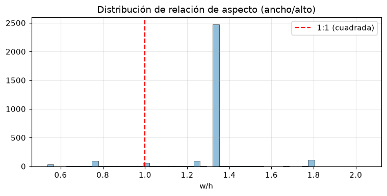

```python
if not disp_img:
    print("OMITIDO.")
else:
    ratios = [w / h for w, h in zip(anchos, altos)]
    casi_cuadradas = np.mean([(0.9 <= r <= 1.1) for r in ratios])
    print(f"Proporción media (alto/ancho invertido->w/h): {np.mean(ratios):.3f}")
    print(f"Imágenes casi cuadradas (0.9 <= w/h <= 1.1): {100 * casi_cuadradas:.1f} %")

    fig, ax = plt.subplots(figsize=(7, 3.6))
    ax.hist(ratios, bins=50, color="#91BFDB", edgecolor="black", linewidth=0.4)
    ax.axvline(1.0, color="red", linestyle="--", label="1:1 (cuadrada)")
    ax.set_title("Distribución de relación de aspecto (ancho/alto)")
    ax.set_xlabel("w/h")
    ax.legend()
    plt.tight_layout()
    plt.show()
```

### 5.3 Brillo (media) y contraste (desviación estándar) por clase

n = 150 imágenes por clase, semilla fija. Sirve para detectar sesgo de captura (iluminación o cámara distintas **entre clases**, lo cual sería un sesgo grave).

|  | brillo mean | brillo std | contraste mean | contraste std |
| --- | --- | --- | --- | --- |
| CBB (bacteriosis) | 110.629997 | 18.680000 | 53.540001 | 8.61 |
| CBSD (rayas marrones) | 114.650002 | 19.080000 | 49.480000 | 8.66 |
| CGM (moteado verde) | 117.949997 | 18.770000 | 51.189999 | 9.86 |
| CMD (mosaico) | 117.949997 | 17.510000 | 53.560001 | 7.97 |
| Saludable | 116.760002 | 20.280001 | 51.700001 | 9.79 |

```
n total: 750 | tiempo 5.7 s
```

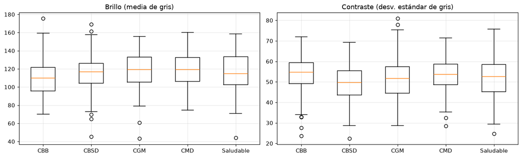

```
Rango de brillo medio entre clases: 110.6 - 118.0 | Rango de contraste: 49.5 - 53.6
```

```python
if not disp_img:
    print("OMITIDO.")
else:
    t0 = time.time()
    filas = []
    for lab in ORDEN:
        g = df.loc[df.label == lab, "image_id"]
        for f in random.sample(list(g), min(150, len(g))):
            with Image.open(RAIZ_IMG / f) as im:
                arr = np.asarray(im.convert("L"), dtype=np.float32)
            filas.append({"label": lab, "archivo": f, "brillo": arr.mean(),
                          "contraste": arr.std()})
    img_stats = pd.DataFrame(filas)
    resumen = img_stats.groupby("label")[["brillo", "contraste"]].agg(["mean", "std"]).round(2)
    resumen.index = [NOMBRE[i] for i in resumen.index]
    display(resumen)
    print(f"n total: {len(img_stats)} | tiempo {time.time() - t0:.1f} s")

    fig, axes = plt.subplots(1, 2, figsize=(13, 4))
    datos_b = [img_stats.loc[img_stats.label == lab, "brillo"] for lab in ORDEN]
    datos_c = [img_stats.loc[img_stats.label == lab, "contraste"] for lab in ORDEN]
    for ax, datos, titulo in ((axes[0], datos_b, "Brillo (media de gris)"),
                              (axes[1], datos_c, "Contraste (desv. estándar de gris)")):
        ax.boxplot(datos)
        ax.set_xticklabels([NOMBRE[i].split(" ")[0] for i in ORDEN])
        ax.set_title(titulo)
    plt.tight_layout()
    plt.show()
    print("Rango de brillo medio entre clases:",
          f"{img_stats.groupby('label').brillo.mean().min():.1f}",
          "-", f"{img_stats.groupby('label').brillo.mean().max():.1f}",
          "| Rango de contraste:", f"{img_stats.groupby('label').contraste.mean().min():.1f}",
          "-", f"{img_stats.groupby('label').contraste.mean().max():.1f}")
```

### 5.4 Montajes visuales por clase (obligatorio)

Respuesta a la consigna: *«determinar si sirve toda la información de las imágenes»* — se muestran muestras aleatorias con **hoja completa, fondo/tallo y bordes**, para decidir qué regiones aportan síntoma y cuáles son ruido (al momento de elegir *augmentations* y ROI).

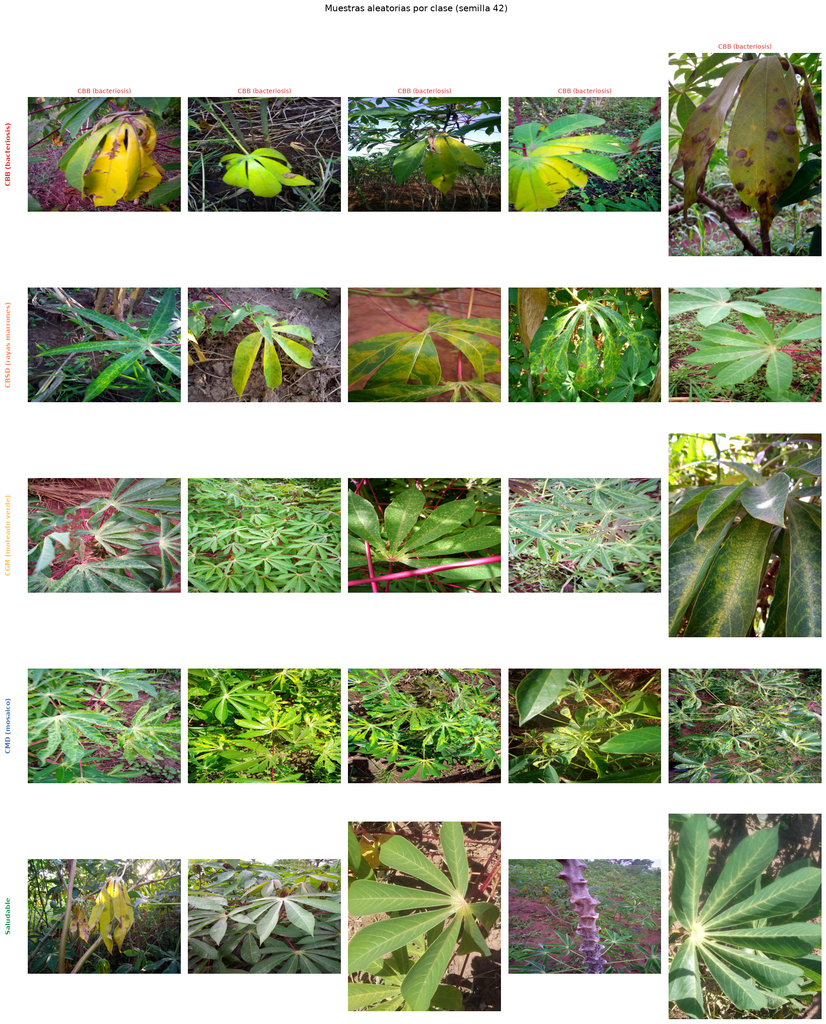

```python
if not disp_img:
    print("OMITIDO.")
else:
    fig, axes = plt.subplots(len(ORDEN), 5, figsize=(17, 4.2 * len(ORDEN)))
    for r, lab in enumerate(ORDEN):
        muestras = random.sample(list(df.loc[df.label == lab, "image_id"]), 5)
        for c, f in enumerate(muestras):
            with Image.open(RAIZ_IMG / f) as im:
                axes[r, c].imshow(im)
            axes[r, c].axis("off")
            if r == 0:
                axes[r, c].set_title(f"\n{NOMBRE[lab]}", fontsize=9, color=PALETA[lab])
            if c == 0:
                axes[r, c].text(-0.15, 0.5, NOMBRE[lab], rotation=90,
                                transform=axes[r, c].transAxes, va="center",
                                fontsize=10, color=PALETA[lab], fontweight="bold")
        for c in range(len(muestras), 5):
            axes[r, c].axis("off")
    fig.suptitle("Muestras aleatorias por clase (semilla 42)", y=1.005, fontsize=13)
    plt.tight_layout()
    plt.show()
```

### 5.5 Imágenes no informativas (reportar, **no borrar** sin decisión documentada)

Percentiles de brillo y contraste sobre una muestra independiente (n = 1,200, semilla 42): se listan las candidatas a casi-negras, casi-blancas o planas (poco detalle).

```python
if not disp_img:
    print("OMITIDO.")
else:
    t0 = time.time()
    files_all = [f for f in os.listdir(RAIZ_IMG) if f.lower().endswith(".jpg")]
    muestra = random.sample(files_all, min(1200, len(files_all)))
    filas = []
    for f in muestra:
        with Image.open(RAIZ_IMG / f) as im:
            arr = np.asarray(im.convert("L"), dtype=np.float32)
        filas.append({"archivo": f, "brillo": arr.mean(), "contraste": arr.std()})
    s = pd.DataFrame(filas)
    p01, p99 = np.percentile(s.brillo, [1, 99])
    casi_negras = s[s.brillo < p01].sort_values("brillo")
    casi_blancas = s[s.brillo > p99].sort_values("brillo", ascending=False)
    planas = s[s.contraste < np.percentile(s.contraste, 1)].sort_values("contraste")
    print(f"n = {len(s)} | percentiles brillo p01={p01:.1f} p99={p99:.1f}")
    print(f"Candidatas casi-negras (<p01): {len(casi_negras)} | casi-blancas (>p99): {len(casi_blancas)}"
          f" | planas (contraste < p01): {len(planas)}")
    print("\nEjemplos mas planos:")
    display(planas.head(5).round(1))
    print(f"Tiempo {time.time() - t0:.1f} s")
    print("Decision: NO se elimina ninguna imagen en el EDA; se deja listado para la etapa de preprocesamiento.")
```

```
n = 1200 | percentiles brillo p01=72.6 p99=157.3
Candidatas casi-negras (<p01): 12 | casi-blancas (>p99): 12 | planas (contraste < p01): 12

Ejemplos mas planos:
```

|  | archivo | brillo | contraste |
| --- | --- | --- | --- |
| 679 | 277532565.jpg | 91.699997 | 18.100000 |
| 419 | train-cbsd-646.jpg | 133.300003 | 21.799999 |
| 729 | 1485753217.jpg | 137.000000 | 22.700001 |
| 715 | 2892378347.jpg | 142.899994 | 23.799999 |
| 89 | 4179630738.jpg | 158.399994 | 24.700001 |

```
Tiempo 8.7 s
Decision: NO se elimina ninguna imagen en el EDA; se deja listado para la etapa de preprocesamiento.
```

## Fase 6 — Propuesta de split y preprocesamiento

Split **estratificado por clase** (70/15/15, semilla 42) y verificación de que `source` también quede repartido en proporción dentro de cada split (evita el sesgo de dominio 2019 vs 2020).

```python
def split_estratificado(df, semilla=42, prop=(0.70, 0.15, 0.15)):
    out = []
    for lab, g in df.groupby("label"):
        idx = g.index.to_numpy().copy()
        rng = np.random.default_rng(semilla)
        rng.shuffle(idx)
        n = len(idx)
        n1 = int(round(prop[0] * n))
        n2 = int(round(prop[1] * n))
        out.append(pd.DataFrame({
            "split": ["entrenamiento"] * n1 + ["validacion"] * n2 + ["test"] * (n - n1 - n2),
            "image_id": idx,
        }))
    res = pd.concat(out, ignore_index=True).set_index("image_id")
    return res

split = split_estratificado(df)
dfx = df.join(split)

print("n por split:")
display(dfx.split.value_counts().to_frame("n").join((100 * dfx.split.value_counts(normalize=True)).round(2).rename("%")))

ct_s = pd.crosstab(dfx.label, dfx.split, margins=True, margins_name="Total")
ct_s.rename(index=NOMBRE, inplace=True)
print("Estratificacion por CLASE (n):")
display(ct_s)

pct_s = (pd.crosstab(dfx.label, dfx.split, normalize="columns") * 100).round(2)
pct_s.rename(index=NOMBRE, inplace=True)
print("% dentro de cada split (debe parecerse a la distribucion global):")
display(pct_s)

ct_src = pd.crosstab(dfx.source, dfx.split, margins=True, margins_name="Total")
print("Reparto de source por split (n) — debe conservar ~81/19 %:")
display(ct_src)
print("Participacion de 2019 por split (%):")
display((100 * pd.crosstab(dfx.source, dfx.split, normalize="columns")).loc[[2019]].round(2))
```

```
n por split:
```

| split | n | % |
| --- | --- | --- |
| entrenamiento | 18435 | 70.0 |
| test | 3951 | 15.0 |
| validacion | 3951 | 15.0 |

```
Estratificacion por CLASE (n):
```

| split label | entrenamiento | test | validacion | Total |
| --- | --- | --- | --- | --- |
| CBB (bacteriosis) | 1044 | 224 | 224 | 1492 |
| CBSD (rayas marrones) | 2433 | 522 | 521 | 3476 |
| CGM (moteado verde) | 2112 | 452 | 453 | 3017 |
| CMD (mosaico) | 10823 | 2320 | 2319 | 15462 |
| Saludable | 2023 | 433 | 434 | 2890 |
| Total | 18435 | 3951 | 3951 | 26337 |

```
% dentro de cada split (debe parecerse a la distribucion global):
```

| split label | entrenamiento | test | validacion |
| --- | --- | --- | --- |
| CBB (bacteriosis) | 5.66 | 5.67 | 5.67 |
| CBSD (rayas marrones) | 13.20 | 13.21 | 13.19 |
| CGM (moteado verde) | 11.46 | 11.44 | 11.47 |
| CMD (mosaico) | 58.71 | 58.72 | 58.69 |
| Saludable | 10.97 | 10.96 | 10.98 |

```
Reparto de source por split (n) — debe conservar ~81/19 %:
```

| split source | entrenamiento | test | validacion | Total |
| --- | --- | --- | --- | --- |
| 2019 | 3408 | 768 | 764 | 4940 |
| 2020 | 15027 | 3183 | 3187 | 21397 |
| Total | 18435 | 3951 | 3951 | 26337 |

```
Participacion de 2019 por split (%):
```

| split source | entrenamiento | test | validacion |
| --- | --- | --- | --- |
| 2019 | 18.49 | 19.44 | 19.34 |

**Reglas anti-fuga y preprocesamiento propuesto**

1. **Sin duplicados entre splits**: la Fase 2.1 verificó 0 duplicados exactos; si en el futuro aparecen *near-duplicates*, se agrupan por hash perceptual **antes** de partir.
2. `image_id` (y por ende el nombre `train-<clase>-…`) **nunca** entra como feature: solo píxeles.
3. Entrada de red: **`Resize(256) + CenterCrop(224)`** (no `resize(224,224)` directo: deforma).
4. Normalización ImageNet (backbones con transfer learning): `mean=[0.485, 0.456, 0.406]`, `std=[0.229, 0.224, 0.225]`.
5. *Augmentations* candidatas (coherentes con lo visto en 5.3): flip horizontal (la hoja no tiene orientación semántica), rotación ±15°, brillo/contraste ±10 %, desplazamiento; **no** usar cambios de color fuertes si los síntomas dependen del color (CMD/CGM justamente).
6. Clases desbalanceadas: `class_weight="balanced"` o *oversampling* dentro del split de **entrenamiento** jamás antes.

## Fase 7 — Conclusiones

**Verificación:** todos los números de esta sección se contrastaron con la salida ejecutada de las celdas anteriores (regla anti-divergencia de la instrucción).

### Resumen

| Dimensión | Resultado |
| --- | --- |
| Registros | 26,337 × 3 (`image_id`, `label`, `source`); sin nulos; sin `image_id` duplicados |
| Imágenes | 26,337 `.jpg` en carpeta plana, 1:1 con el CSV (0 faltantes / 0 sobrantes); ≈3.09 GiB |
| Duplicados exactos | **0** (SHA-1 completo de los 26,337 archivos) |
| Legibilidad | 0 imágenes corruptas en la muestra de 3,000; todas en modo RGB |
| Clases (n y % sobre el total) | CBB 1,492 = 5.67 % · CBSD 3,476 = 13.20 % · CGM 3,017 = 11.46 % · **CMD 15,462 = 58.71 %** · Saludable 2,890 = 10.97 % |
| Desbalance | ratio máx/mín = **10.36 : 1** (CMD vs CBB) |
| Fuentes | 2020: 21,397 = 81.24 % · 2019: 4,940 = 18.76 % |
| Filtrado por nombre | las 4,940 de 2019 son `train-<clase>-NNN.jpg` con 100 % de coherencia con `label` → **no usar el nombre como feature** |
| Dimensiones | dominante 800×600 80.4 % del muestreo), 132 tamaños distintos, mediana 119.5 KB |
| Aspecto | media w/h = 1.30; solo 3.4 % casi cuadradas → `Resize(256)+CenterCrop(224)` |
| Brillo/contraste por clase | promedios casi idénticos entre clases (brillo 110.6–118.0, contraste 49.5–53.6) → **sin sesgo de captura por clase** |
| Imágenes no informativas | listadas por percentiles; **no se borra ninguna** sin decisión documentada |

### Decisiones

1. **Métricas del trabajo:** macro-F1, balanced accuracy, ROC-AUC/PR-AUC y matriz de confusión normalizada por fila; el accuracy crudo se reporta solo como referencia.
2. **Costo asimétrico:** penalizar más el error Saludable ↔ Enferma (consigna de la cátedra).
3. **Split estratificado por clase** con semilla 42 (70/15/15), verificado también por `source` para mitigar el sesgo de dominio entre 2019 y 2020.
4. **Preprocesamiento:** `Resize(256) + CenterCrop(224)`, normalización ImageNet, augmentaciones acotadas (sin alterar fuertemente el color).

### Pendientes / lo que falta

- Decisión de política sobre imágenes muy planas o casi monocromáticas (listadas en 5.5).
- Evaluar *near-duplicates* con hash perceptual (pHash) antes del split definitivo.
- Confirmar con muestra visual si el fondo/tallo/raíz aportan síntoma o solo ruido (montajes 5.4).

## Fase 8 — Reproducibilidad y entregables

**Regla de carpetas:** el código (`.ipynb`, `.py`) vive en la **raíz**; todo PDF/HTML de resumen o explicación va a **`reportes/`**; los `.html` **solo se generan si se piden explícitamente**.

**Google Colab:** subir `labels.csv` (celda 2 lo detecta); para las celdas de imágenes subir `mandioca.zip` y ejecutar la celda siguiente.

**Ejecución desde terminal (gate de calidad):**

```
python -m nbconvert --to notebook --execute --inplace --ExecutePreprocessor.timeout=1800 01_EDA_mandioca.ipynb
python -m nbconvert --to script 01_EDA_mandioca.ipynb
python -m nbconvert --to html --embed-images --output-dir reportes 01_EDA_mandioca.ipynb   # solo si se pide
# PDF desde el HTML con Edge headless (no hay pandoc):
#   msedge --headless --no-pdf-header-footer --print-to-pdf=".../reportes/01_EDA_mandioca.pdf" "file:///.../reportes/01_EDA_mandioca.html"
```

```python
# Colab: descomentar para subir el dataset de imagenes y descomprimirlo.
# import zipfile
# from google.colab import files
# upload = files.upload()            # subir mandioca.zip
# with zipfile.ZipFile(list(upload)[0]) as z:
#     z.extractall("datos")
# print("listo")
```

```python
import nbformat
_nbk = nbformat.read(str(Path(r"C:\Users\Fabricio\Desktop\final_inteligencia\01_EDA_mandioca.ipynb")), 4)
print("Celdas:", len(_nbk.cells),
      "| markdown:", sum(c.cell_type == "markdown" for c in _nbk.cells),
      "| código:", sum(c.cell_type == "code" for c in _nbk.cells))
```

```
Celdas: 38 | markdown: 19 | código: 19
```